# Denny Lab Wholebrain Pipeline Demo

# 12 Plotting functions

Hooray! All of this hard work will allow use to generate some beautiful and hopefully informative plots (for real datasets). First there are some conventions to note for plotting functions. Unlike all the other package functions presented here, we will *not* be assigning the output of a plotting function to our experiment object. There is no return value for plotting functions. This is because no analysis is being done and the primary output that we want is either a graphics window, or an image saved to our output folder.

Almost all the functions will have parameters allowing you to specify the height and width in inches, the image extension (e.g. “.png”, “.jpg”), as well as colors (or color palettes) to save your plot as. Some of the functions will allow you to adjust the xlim and the ylim of your axes in order to fit the data. Pay close attention to the help pages to see what plot characteristics are customizable for each function.

## 12.1 Plot percentage colabel

The first thing we may want to do plot is percentage of colabelled counts over a given channel. This can be done in Prism using the ‘.csv’ data files produced by `get_percent_colabel`. This may be a more flexible and preferable for publications. However, it is time-consuming to graph in Prism so for quick visualizations you can use the handy function `plot_percent_colabel`.

This function is designed to take up to two mouse attributes to “map” to the respective graphs aesthetics of color and pattern to display on a bar plot. The `rois` parameter allows for selective plotting of specific regions or subregions of interest. Below we will plot any regions that are subregions of the the Dentate Gyrus or the Cornu Ammonis.

```r
plot_percent_colabel(sundowning,
                     channel = "eyfp",
                     color_mapping = "sex",
                     colors = c("#952899", "#358a9c"),
                     pattern_mapping = "group",
                     plot_individual = TRUE,
                     print_plot = TRUE,
                     save_plot = TRUE,
                     rois = c("DG", "CA"),
                     ylim = c(-5,50),
                     image_ext = ".svg")
```

[figure not shown]

> Note: The optional package `ggpattern` is required for mapping to the `pattern` aesthetic using the `pattern_mapping` parameter so make sure it is installed before running this function.

Plotting using just one attribute is also possible. The `color` aesthetic takes precedence over the `pattern` aesthetics, so just omit the `pattern_mapping` parameter, and it will take the default value of `NULL`. Below we’ll only use the `color_mapping` parameter and set it to `group` to plot a separate bar for each experimental group.

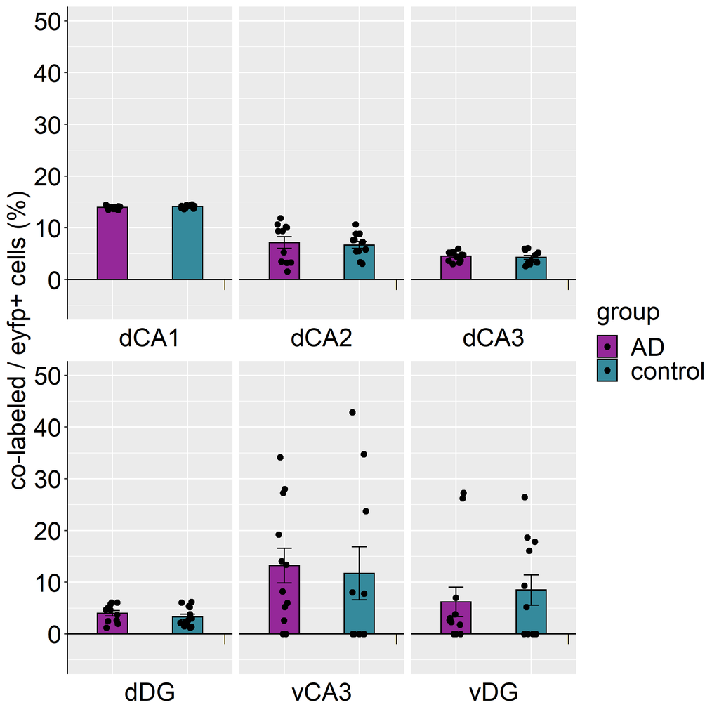

```r
plot_percent_colabel(sundowning,
                     channel = "eyfp",
                     color_mapping = "group",
                     colors = c("#952899", "#358a9c"),
                     plot_individual = TRUE,
                     print_plot = TRUE,
                     save_plot = TRUE,
                     error_bar = "sem",
                     rois = c("DG", "CA"),
                     ylim = c(-5, 50))
```

## 12.2 Plot heatmaps of region correlations

We can automatically plot heatmaps of the pairwise region correlations using the function `plot_correlation_heatmaps()`. Here we simply specify the name of the correlation list and the respective colors (in a hexadecimal string) corresponding to the channels that were specified in `get_correlations()`

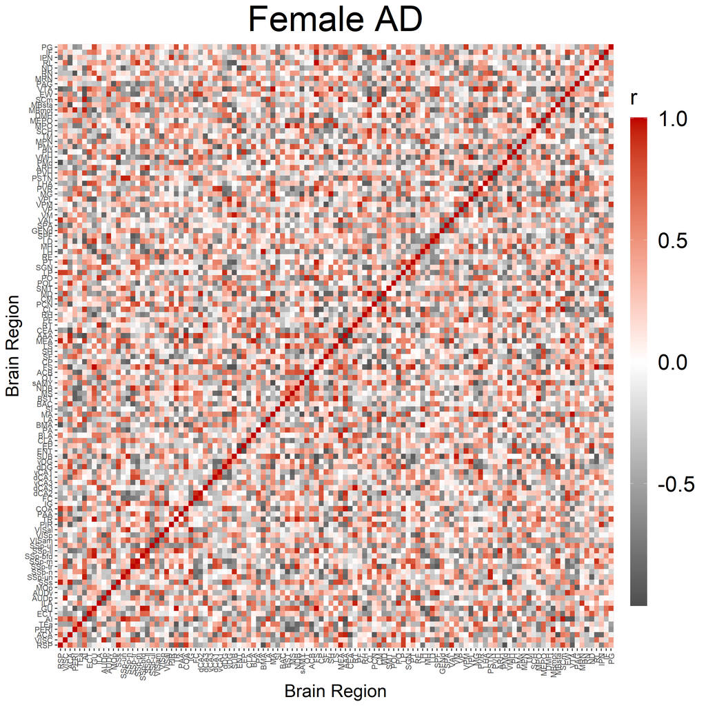

Example heatmap of the cfos channel

```r
plot_correlation_heatmaps(sundowning,
                          correlation_list_name = "female_AD",
                          colors = c("#be0000", "#00782e", "#f09b08"),
                          )
```

## 12.3 Plot permutation analysis results (volcano plots & parallel coordinate plots)

A volcano plot can show us the the pairwise regions whose correlations are significantly different between analysis groups. The colored dots represent the region pairs that are significantly different between the groups, and have pearson correlation coefficient differences that are greater than +/- 1.

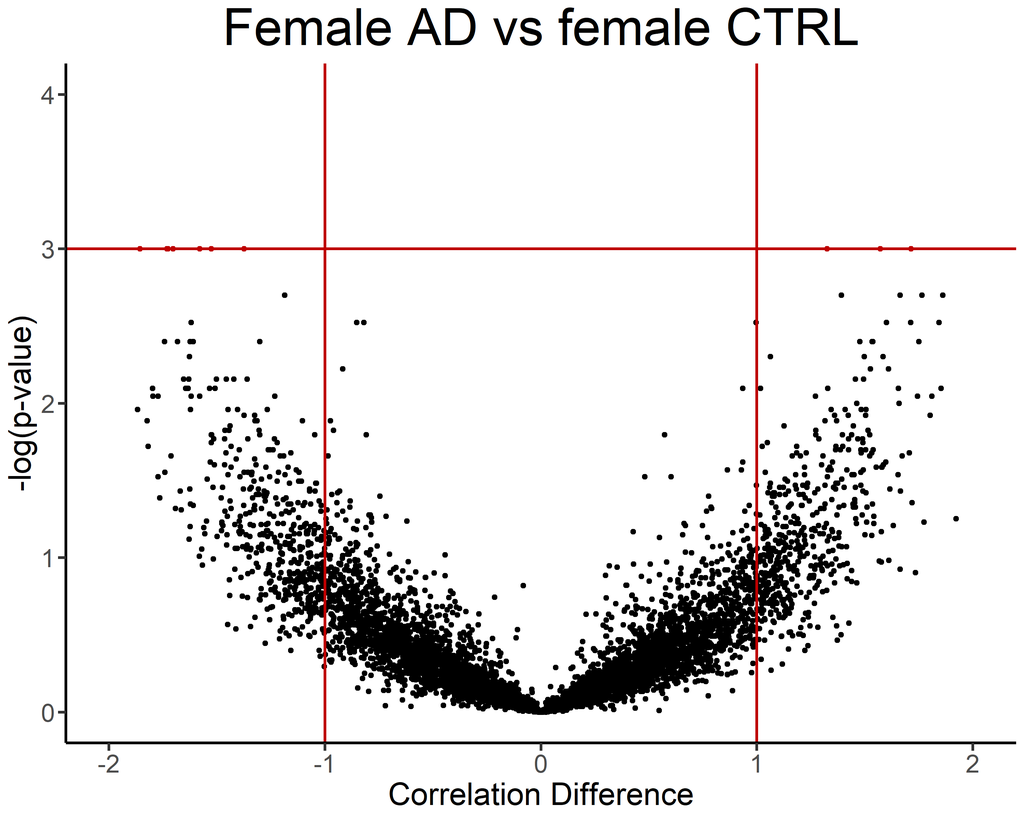

Volcano plot of just the cfos channel

```r
volcano_plot(sundowning,
             permutation_comparison = "female_AD_vs_female_control",
             channels = c("cfos", "eyfp", "colabel"),
             title = "Female AD vs female CTRL",
             ylim = c(0,4))
```

A parallel coordinate plot allows us to see which actual region pairs are different between our two analysis groups and in which direction their correlation coefficients change. Only region pairs from the volcano plot that are above the alpha level and have correlation coefficient differences greater than absolute one are included in this graph.

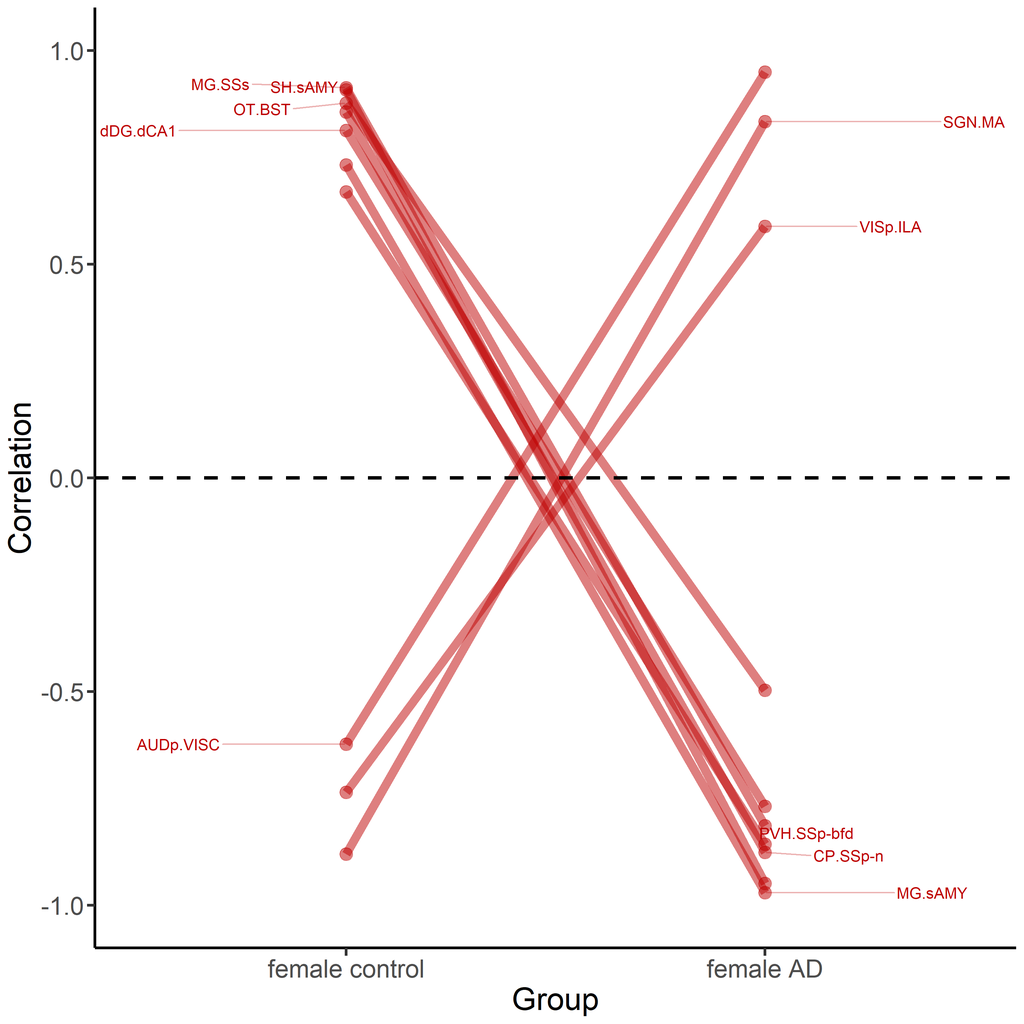

parallel coordinate plot of just the cfos channel

```r
parallel_coordinate_plot(sundowning,
                         permutation_comparison = "female_AD_vs_female_control",
                         channels = c("cfos", "eyfp", "colabel"),
                         )
```

## 12.4 Plot network graphs

The `plot_networks()` functions will automatically plot the output of `create_networks()`. You must specify the name of the network you want to plot. There a some customizable features such as setting the edge color (taken as a hexadecimal string) for positively correlated connections. The default color is “firebrick”. Below we will plot the network for the cfos channel in only female AD mice.

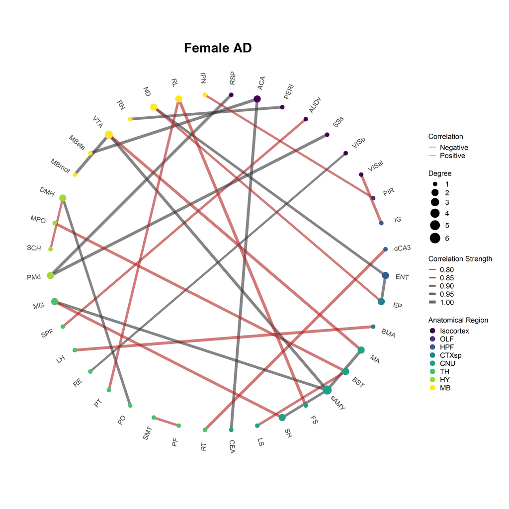

AD female network graph for the cfos channel

```r
plot_networks(sundowning,
              network_name = "female_AD",
              channels = "cfos",
              title = "Female AD",
              edge_color = "firebrick"
              )
```

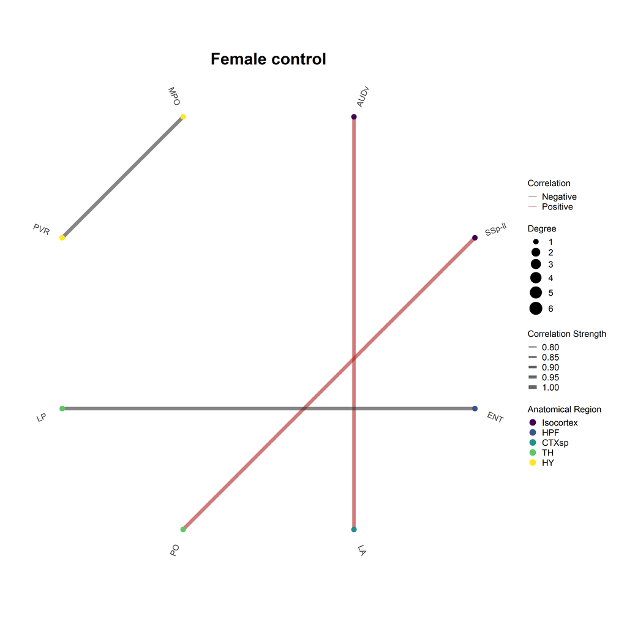

Control female network graph for cfos channel

```r
plot_networks(sundowning,
              network_name = "female_control",
              channels = "cfos",
              title = "Female control",
              edge_color = "firebrick"
              )
```

## 12.5 Plot network summary statistics

### Degree distributions

After we have plotted our network graphs, it is useful to also plot the summary statistics and measurements of node centrality within our networks.

Degree is a measurement of how many nodes each node is connection to. We can plot a stacked histogram of degree distributions of a network in a stacked histogram using the function `plot_degree_distribution()`. Remember that we were able to summarize multiple networks using the function `SMARTR::summarise_networks()`, so we can actually plot both networks on one graph. Check out the example below for plotting the `female_AD` group and the `female_control` networks.

If you want to change the legend label of your groups, map the corresponding `network_name` to the label you want using the `labels` parameter. Below is an example of mapping the `female_AD` group and `female_control` group to the legend labels “Female AD” and “Female CTRL” respectively.

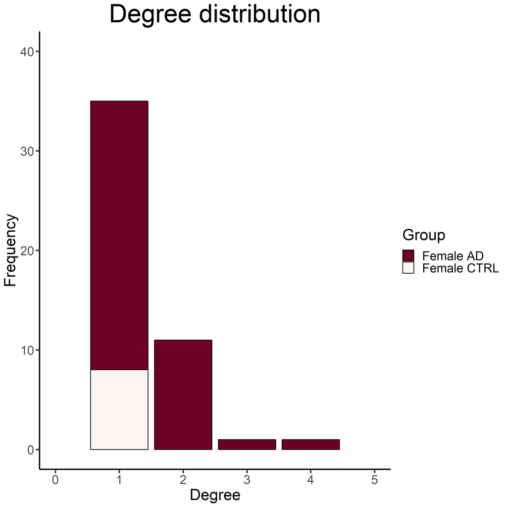

```r
plot_degree_distributions(sundowning,
                          color_palettes = "reds",
                          channels = "cfos",
                          title = "Degree distribution",
                          labels = c("female_AD" = "Female AD",
                                     "female_control" = "Female CTRL"),
                          height = 10,
                          width = 10,
                          xlim = c(0, 5),
                          ylim = c(0, 40),
                          save_plot = TRUE,
                          print_plot = TRUE)
```

### Mean degree

We can also plot the mean degree between the networks on a bar graph. Here the parameter `rev_x_scale` allows us the change the order of our groups on the barplot. In this case, setting it to `TRUE` will keep the control analysis group on the left.

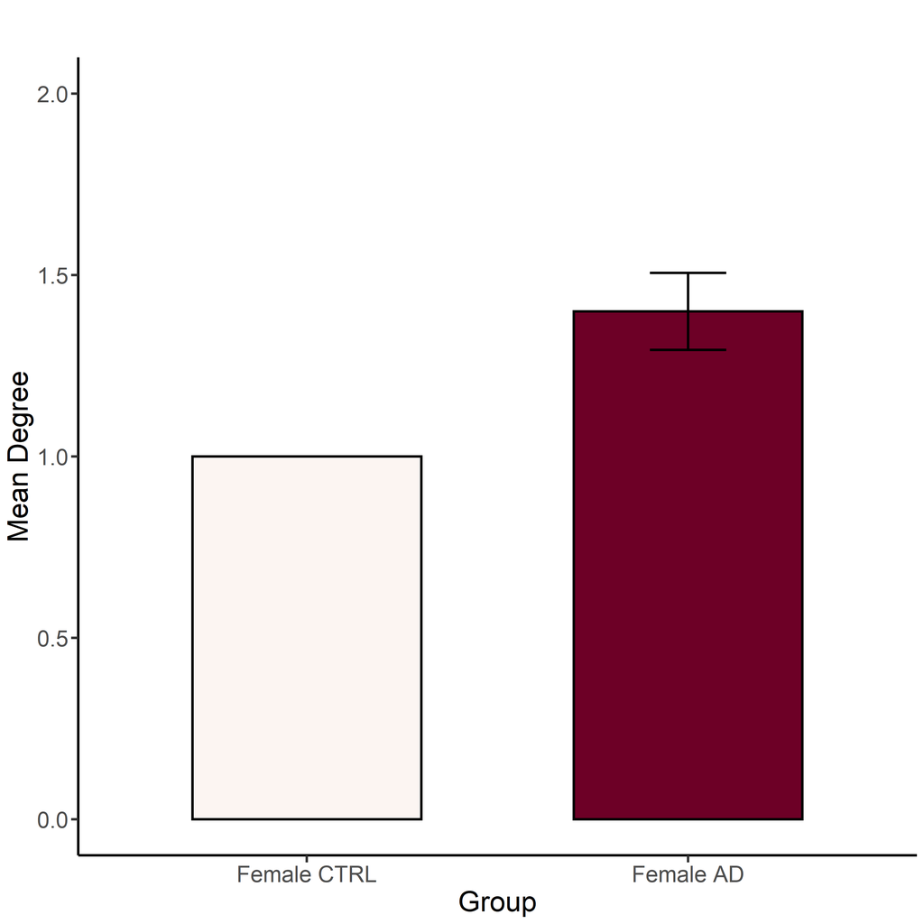

```r
plot_mean_degree(sundowning,
                 color_palettes = c("reds"),
                 channels = c("cfos"),
                 title = "",
                 labels = c("female_AD" = "Female AD",
                            "female_control" = "Female CTRL"),
                 ylim = c(0, 2),
                 height = 10,
                 width = 10,
                 rev_x_scale = TRUE,
                 )
```

Also, Keep in mind that you may need to tweak the `ylim` of your graph to ensure that all the data can fit within the axes limits. If one bar seems to not plot, try changing this parameter first.

### Clustering coefficient

The clustering coefficient is a measurement of how many neighboring nodes to a given node are mutually connected, i.e. the strength of local clusters. We can use the function `plot_mean_clust_coeff()` to compare the average clustering coefficient for each network.

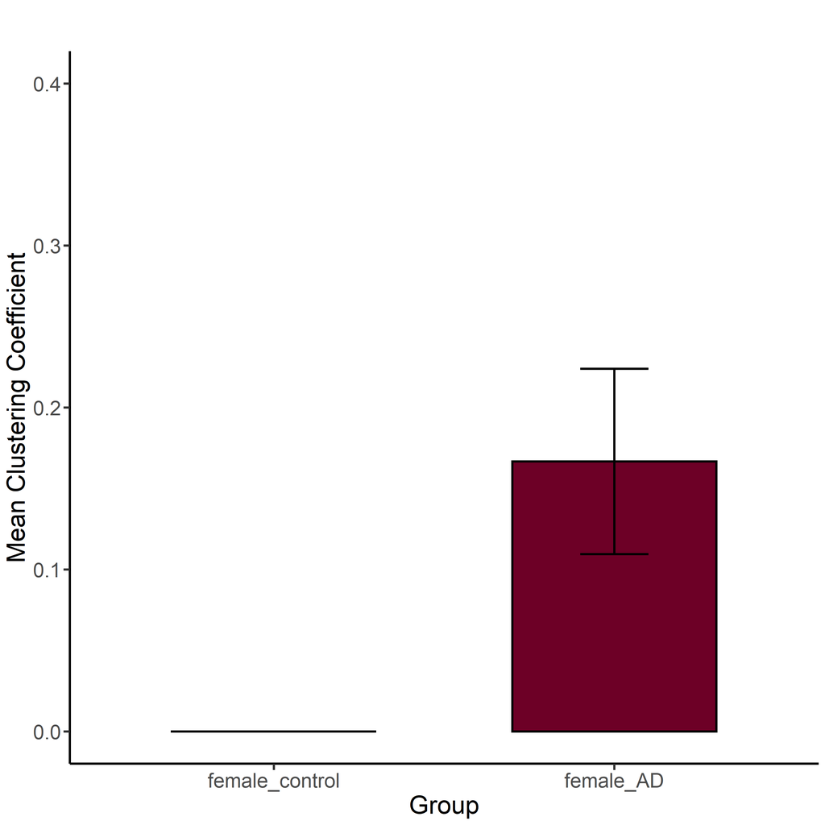

```r
plot_mean_clust_coeff(sundowning,
                      color_palettes = c("reds"),
                      channels = "cfos",
                      title = "",
                      rev_x_scale = TRUE,
                      ylim = c(0, 0.4),
                      height = 10,
                      width = 10
                      )
```

### Mean global efficiency

Efficiency is a measure of the average number of nodes necessary to cross to get from any node to another. Efficiency is the inverse of the average shortest path. To make an analogy, think about the game “6 degrees of Kevin Bacon”.

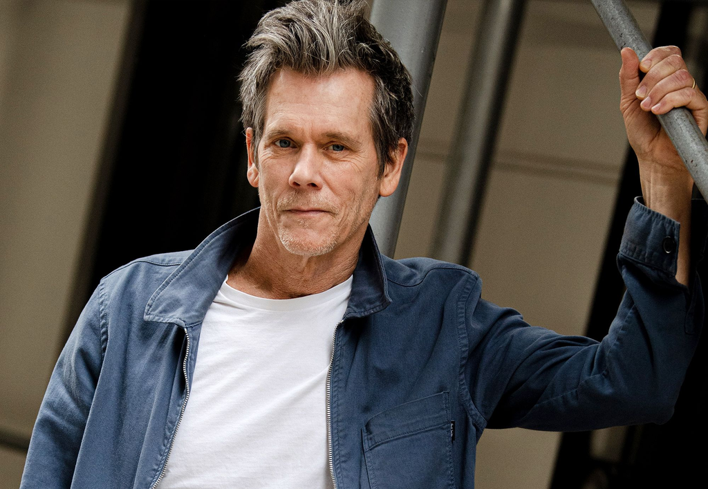

Kevin Bacon in his natural element

If one person in our lab is 6 degrees away from Kevin, while another is only 3 degrees away (distant cousins, I guess). Then the efficiency in those two people’s connection to Kevin Bacon is 1/average_degree = 1/4.5.

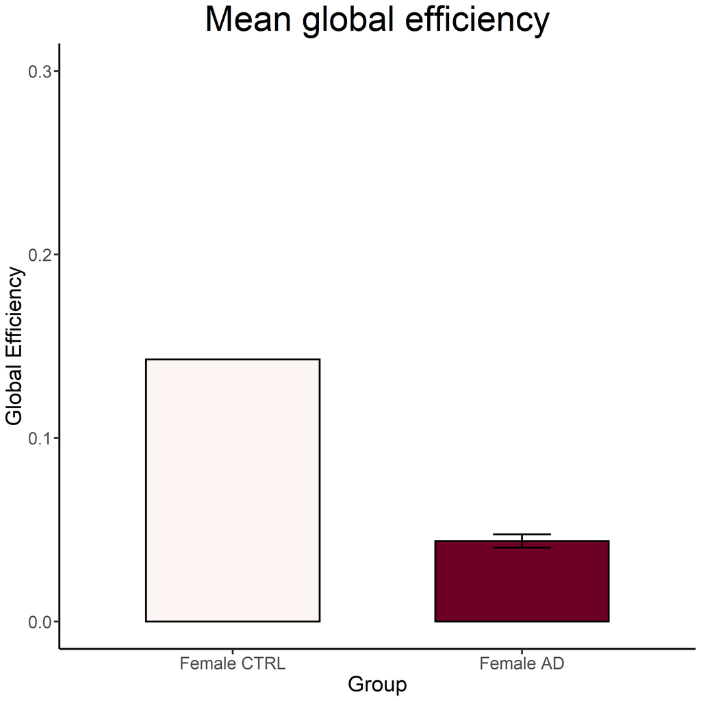

```r
plot_mean_global_effic(sundowning,
                       channels = "cfos",
                       color_palettes = "reds",
                       labels = c("female_AD" = "Female AD",
                            "female_control" = "Female CTRL"),
                       title = "Mean global efficiency",
                       ylim = c(0, 0.3),
                       height = 10,
                       width = 10,
                       rev_x_scale = TRUE)
```

### Mean betweenness centrality

A related concept is betweenness centrality. This measures how many shortest paths pass through a given node, and it is one indication of how important or central a given node is.

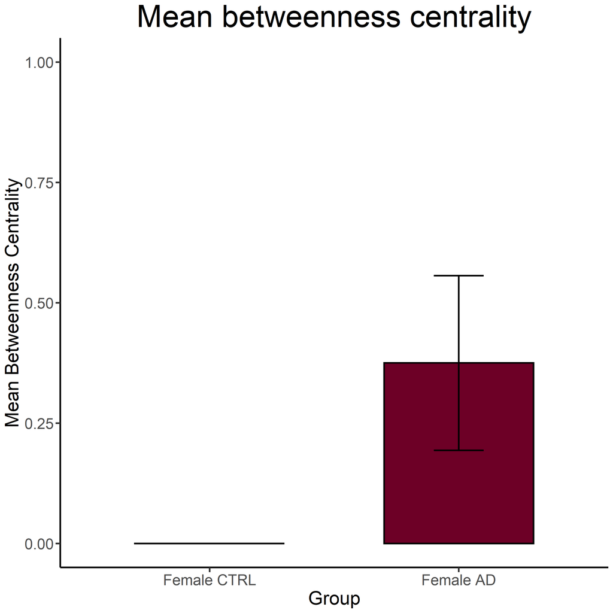

```r
plot_mean_between_centrality(sundowning,
                             color_palettes = "reds",
                             channels = "cfos",
                             title = "Mean betweenness centrality",
                             labels = c("female_AD" = "Female AD",
                                        "female_control" = "Female CTRL"),
                             ylim = c(0, 1),
                             height = 10,
                             width = 10,
                             rev_x_scale = TRUE)
```

### Region degree

For a single network, We can also examine which individual regions have the highest degree. This will give use an indication of how central some of these regions are in their network and presumably related to how functionally important they are. We can do this by plotting region degrees in descending order.

The example below plots the “female_AD” network region degrees.

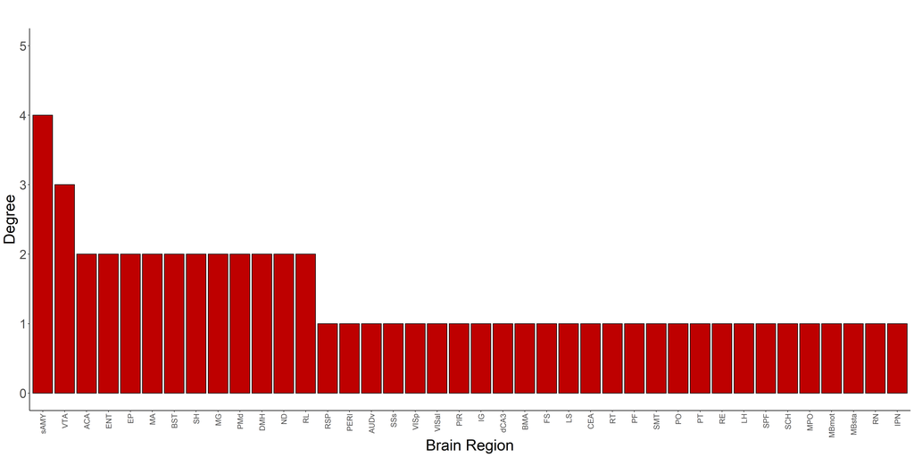

```r
plot_degree_regions(sundowning,
                    network = "female_AD",
                    channels = "cfos",
                    colors = c("#be0000", "#00782e"),
                    ylim = c(0, 5),
                    title = ""
                    )
```

### Region betweenness

Similarly to degree, we can plot the the betweenness centrality for individual regions in descending order.

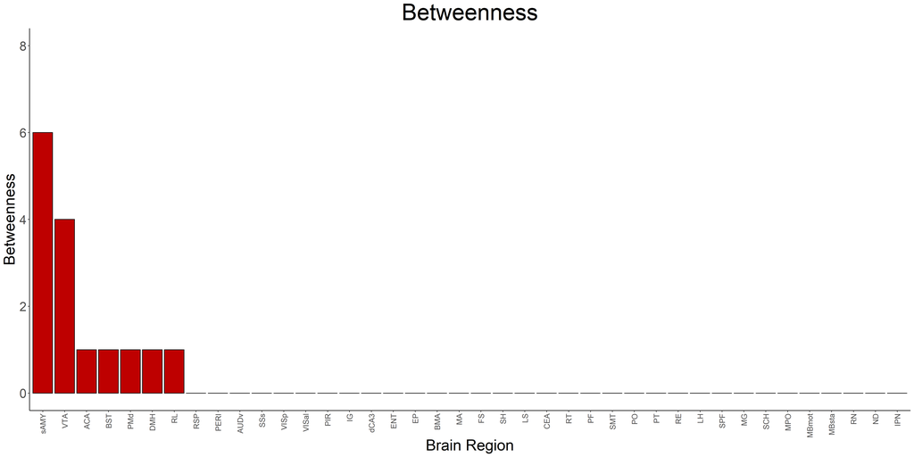

```r
plot_betweenness_regions(sundowning,
                         network = "female_AD",
                         channels = "cfos",
                         colors = "#be0000",
                         title = "Betweenness",
                         ylim = c(0, 8))
```

# 13 Scripting

Scripting in R is more advanced topic, however it can save a ton of time in automating tasks that are repetitive, such as object creation or looping registrations across all the slices. The following sections will cover different scripts that can help automate these tasks.

## 13.1 Creating mouse and slice objects using a script

We can make our lives a little easier (and more organized) by reading a csv file that initially contains all of the mouse and slice attribute data prior to creating the objects.

```r
# This batch script:
# Reads the parameters from a csv file
# Auto creates the mouse and slice objects
# Automatically saves the mouse objects in designated mouse output folder

# Dependencies:
library(SMARTR)
library(tidyverse)
library(magrittr)
library(stringdist)


# Read the dataframe
csv_path <-"V:\\Michelle Jin\\Sundowning\\MasterSliceMouseObject_9.21.2021.csv"

#_____________________ autocreate mouse objects _______________________________

df <- read_csv(csv_path, na = c("", "NA"))


# Isolate columns with mouse metadata and slice metadata
mouse_cols <- names(df[1:(which(names(df) == "slice") - 2)])
slice_cols <- names(df[which(names(df) == "slice"):length(df)])

# select mouse column data and collapse redundant information
mice_info <- df %>% dplyr::select(all_of(mouse_cols)) %>% distinct()

# Autocreate each mouse object and save in the mouse directory as it's output folder
for (m in 1:length(mice_info$mouse)){

  my_mouse <- mouse(mouse_ID = mice_info$mouse[m],
                    sex = mice_info$sex[m],
                    age = mice_info$age[m],
                    cre_genotype = mice_info$cre_genotype[m],
                    reporter = mice_info$reporter[m],
                    strain = mice_info$strain[m],
                    experiment = mice_info$experiment[m],
                    group = mice_info$group[m],
                    drug = mice_info$drug[m],
                    cohort = mice_info$cohort[m],
                    output_path = mice_info$mouse_path[m])


  # Save the mouse, then remove it from the environment
  assign(paste0("mouse_", mice_info$mouse[m]), my_mouse)
  eval((parse(text=paste0("save_mouse(mouse_", mice_info$mouse[m],")"))))
  eval((parse(text=paste0("rm(mouse_", mice_info$mouse[m],")"))))

}

#_____________________ autocreate slice objects _______________________________

# For each new slice
# Detect if the mouse has changed
# load the mouse
# populate the slice info
# Add it to the mouse
# check if the next slice belongs to the same mouse
# if not, save the mouse and delete it from the environment
# move onto next mouse

change_mouse <- TRUE
for (s in 1:length(df$slice)){

  # Check if this is a skipped slice. Skip current slice if it is.
  if (isTRUE(df$`Skip (y)`[s] == "y")) {
     next
  }

  if (change_mouse && s != 1){
    # search, save, then remove current mouse
    eval((parse(text=paste0("save_mouse(", cur_mouse, ")"))))
    eval(parse(text=paste0("rm(", cur_mouse, ")")))

    # Load the new mouse
    load(file.path(df$mouse_path[s], paste0("mouse_", df$mouse[s], ".RDATA")))
    cur_mouse <- ls()[amatch("mouse_", ls(), maxDist = 4)]
    change_mouse <- FALSE
  } else if (s == 1) {
    # Load the new mouse
    load(file.path(df$mouse_path[s], paste0("mouse_", df$mouse[s], ".RDATA")))

    # current mouse
    cur_mouse <- ls()[amatch("mouse_", ls(), maxDist = 4)]
    change_mouse <- FALSE
  }


  # Fill the hemisphere information
  if (is.na(df$hemisphere[s])){
    hemi <- NULL
  } else {
    hemi <- df$hemisphere[s]
  }

  # Populate the slice information
  my_slice <- slice(slice_ID = df$slice[s],
                    hemisphere = hemi,
                    coordinate = df$`atlas coordinate`[s],
                    registration_path = df$registration_path[s])

  eval(parse(text = paste0(cur_mouse, "<- add_slice(", cur_mouse, ", my_slice)")))
  print(  eval(parse(text = paste0(cur_mouse))))

  # get current mouse number
  cur_mouse_no <- str_split(cur_mouse, "_") %>% unlist()
  cur_mouse_no <- cur_mouse_no[-1] %>% as.double()

  if (s == length(df$mouse)){
    # Save if its the last slice in a mouse
    eval((parse(text=paste0("save_mouse(", cur_mouse, ")"))))
  } else if (df$mouse[s + 1] != cur_mouse_no){
    change_mouse = TRUE
  }

}
```

## 13.2 Looping through the registration process

We can also automatically loop through the registration process all the slices in a given mouse object. The script below is an example for how to process `mouse_325.`It will loop through each slice, setting the correct ID and hemisphere parameters, and allow for interactive adjustment of the `brain.threshold` and registration.

```r
# Autolooping script to do set a brain threshold and do registrations
# Use this script when you are trying to register all of the slices in a mouse object.
# First go to the mouse folder on the server and load the mouse object.
# Set the current slice you want to start processing. This script will loop through the remaining slices.
# This script will first interactively ask you to try setting different brain thresholds prior to registration each slice.
# I recommend a brain threshold setting between 6-12. Anything above this may be too sensitive.


#_____________ Set the user-defined variables below _________________

# Enter the name of the mouse you are processing as a string
mouse_name <- "mouse_325"

# Enter the number of the slice where you left off/want to start
curr_slice <- 1


#______ End of user defined variables. Highlight and run the code below to start the registration loop _________________

# Load library
library(SMARTR)

# Set current mouse to the user specified name
eval((parse(text=paste0("mouse <- ", mouse_name))))

# Process the slice names for looping
slices <- names(mouse$slices)
rights_hemi <- grep("_right", slices)
lefts_hemi <- grep("_left", slices)

# remove hemispheres from slice names
slice_ID <- gsub("_right", "", slices)
slice_ID <- gsub("_left", "", slice_ID)


# Set brain threshold and register
for (s in curr_slice:length(slices)){
  if(s %in% rights_hemi){
    hemi <- "right"
  } else if (s %in% lefts_hemi){
    hemi <- "left"
  } else {
    hemi <- NULL
  }

  # Adjust the brain filter
  filter <- adjust_brain_outline(mouse$slices[[slices[s]]])

  ## Print information about slice before the registration
  coordinate <- attr(mouse$slices[[slices[s]]],"info")$coordinate
  message(paste0("\n\nYour current slice is: ", slice_ID[s],
                 "\n The coordinate is:", coordinate,
                 "\nThe hemisphere is: ", ifelse(is.null(hemi), "both", hemi)))

  # Interactive registration
  mouse <- register(mouse,
                        slice_ID = slice_ID[s],
                        hemisphere = hemi,
                        filter = filter)

  # Automatically update the mouse object
  eval((parse(text=paste0(mouse_name, " <- mouse"))))
}


#_____________ Run the code below to periodically save your work  _________________

# I recommend doing this after every registration
eval((parse(text=paste0("save_mouse(", mouse_name, ", timestamp = TRUE)"))))
```